# Homework 7

Luke Daniels

3/3/2018

```r
library(ggplot2)
```

The following represents a fake data set for the metabolic rates of crickets at two different temperature treatments (High, Low). For simplicity, there are only two generic temperature treatments. Metabolic rate is measured in ml O2/gram / Hour. This fake data will be analyzed using an ANOVA test.

### *1) Go back to your “thinking on paper” exercise, and decide on a pattern that you might expect in your experiment if a specific hypothesis were true.*

Please Refer to Homework 2 on main portfolio.

### *Question 2.) Specifying sample size, means, and variances for each group*

Metabolic rate is expected to increase at higher temperatures. There will likely be a corresponding increase in standard deviation as temperatures increase.

### *Question 3.) Write a function to create a data set that uses the specified parameters*

- The arguments of this function are the treatment names, sizes and means in vector form.
- The response variable “MetaRate” is created from the arguments.
- The treatment groups variable “TGroup” is created by replicating the values in both Name and Size vector
- The function returns the data frame with the response variable and treatment groups given our parameters

```r
 myFunction <- function(nGroup = 2, nName1 = c("Low", "High"),
                          nSize1 = c(50,50), nMean1 =c(1.5,2)){
    ID <- 1:100
    resVar <- c(rnorm(n=nSize1[1], mean= nMean1[1],sd = .5),
                rnorm(n=nSize1[2], mean= nMean1[2],sd = .75))
    TGroup <- rep(nName1,nSize1)
    ANOdata <- data.frame(ID, TGroup, resVar)
  return(ANOdata)
  }
```

Our desired data frame is created by assigning myFunction to the global environment

```r
myDF <- myFunction()
```

### *Question 4.) Now write a simple function to analyze the data (probably as an ANOVA or regression analysis, but possibly as a logistic regression or contingency table analysis. Write another function to generate a useful graph of the data.*

```r
 myDF <- myFunction()

  AnoFunction <- function(data=myDF){
  ANOmodel <- aov(myDF$resVar ~ myDF$TGroup, data = myDF)
  ANOSummary <- summary(ANOmodel)
  return(ANOSummary)
  }

AnoFunction()
```

```
##             Df Sum Sq Mean Sq F value  Pr(>F)
## myDF$TGroup  1   4.63   4.634    9.37 0.00285 **
## Residuals   98  48.46   0.495
## ---
## Signif. codes:  0 '***' 0.001 '**' 0.01 '*' 0.05 '.' 0.1 ' ' 1
```

The function generates the following data:

```r
myFunction()
```

| ID | TGroup | resVar |
| --- | --- | --- |
| 1 | Low | 1.1159298 |
| 2 | Low | 1.6688823 |
| 3 | Low | 2.0741173 |
| 4 | Low | 1.1425504 |
| 5 | Low | 1.3379061 |
| 6 | Low | 2.3689761 |
| 7 | Low | 2.0952088 |
| 8 | Low | 1.6614507 |
| 9 | Low | 1.6111971 |
| 10 | Low | 1.7223976 |

[output cut: 90 more lines]

Using ggplot2

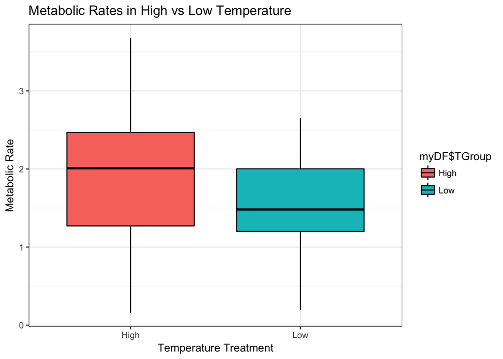

```r
ANOplot <- ggplot(data = myDF, aes(x=myDF$TGroup,y=myDF$resVar, fill = myDF$TGroup))+
                    geom_boxplot(colour = "Black")+
  scale_y_continuous(name = "Metabolic Rate")+
  scale_x_discrete(name = "Temperature Treatment") +
  ggtitle("Metabolic Rates in High vs Low Temperature")+
  theme_bw()
  ANOplot
```

### *Question 5.) Try running your analysis multiple times to get a feeling for how variable the results are with the same parameters, but different sets of random numbers.*

Repeating the function with the same parameters yields:

```r
# 1.) 0.0837  2.) 0.00721  3.) 0.000635  4.) 0.000124 5.) 0.0019  6.) 0.0267  7.)0.0011

# 8.)0.000374   9.)0.00112  10.)0.0386  11.)0.00052  12.) 0.00093  13.) 0.049
```